# Predição de Votação de Deputados

Matheus Leal

07 de novembro de 2018

**Carregando bibliotecas* necessárias**

**Carregando os dados e removendo informações pouco relevantes, como nome, cargo, número, sequencial do candidato e ocupação**

```r
train <- read.csv("./train.csv")
train <- train %>% select(-cargo, -nome, -sequencial_candidato, -ocupacao)
train[is.na(train)] <- 0
```

**1. Usando todas as variáveis disponíveis, tune (usando validação cruzada): (i) um modelo de regressão Ridge, (ii) um modelo de regressão Lasso e (iii) um modelo KNN. Para os modelos de regressão linear, o parâmetro a ser tunado é o lambda (penalização dos coeficientes) e o KNN o número de vizinhos.**

#### Usando validação cruzada

```r
fitControl <- trainControl(method = "cv",
                           number = 10,
                           search = "random")
preProcValues <- c("center", "scale", "nzv")
```

#### (i) O modelo de regressão Ridge

```r
model.ridge <- train(votos ~ .,
               data = train,
               trControl = fitControl,
               method = "ridge",
               preProcess = preProcValues,
               tuneLength = 15)
model.ridge
```

```
## Ridge Regression
##
## 7476 samples
##   19 predictor
##
## Pre-processing: centered (32), scaled (32), remove (49)
## Resampling: Cross-Validated (10 fold)
## Summary of sample sizes: 6729, 6728, 6728, 6728, 6728, 6729, ...
## Resampling results across tuning parameters:
##
##   lambda        RMSE      Rsquared   MAE
##   1.031154e-05  39113.25  0.3945467  16348.62
##   2.971823e-05  39113.91  0.3945407  16348.75
##   7.648806e-05  39115.49  0.3945263  16349.04
##   1.668854e-04  39118.55  0.3944980  16349.59
##   1.296040e-03  39156.34  0.3941311  16355.81
##   1.652158e-03  39167.84  0.3940152  16357.48
##   2.026988e-03  39179.68  0.3938949  16359.11
##   3.490212e-03  39223.01  0.3934482  16364.31
##   9.574590e-03  39363.18  0.3920181  16374.58
##   7.812353e-02  40019.37  0.3882094  16298.58
##   2.054584e-01  40935.67  0.3865904  16166.29
##   2.259082e-01  41090.46  0.3863749  16160.24
##   6.328502e-01  44694.34  0.3827507  16667.57
##   1.088405e+00  49458.80  0.3799824  18221.68
##   3.029257e+00  69475.28  0.3746666  27437.13
##
## RMSE was used to select the optimal model using the smallest value.
## The final value used for the model was lambda = 1.031154e-05.
```

#### (ii) O modelo de regressão Lasso

```r
model.lasso <- train(votos ~ .,
                     data = train,
                     trControl = fitControl,
                     method = "lasso",
                     preProcess = preProcValues,
                     tuneLength = 15)
model.lasso
```

```
## The lasso
##
## 7476 samples
##   19 predictor
##
## Pre-processing: centered (32), scaled (32), remove (49)
## Resampling: Cross-Validated (10 fold)
## Summary of sample sizes: 6728, 6728, 6729, 6729, 6728, 6728, ...
## Resampling results across tuning parameters:
##
##   fraction    RMSE      Rsquared   MAE
##   0.04225047  38512.11  0.4145641  16341.36
##   0.12701449  39011.83  0.4107561  16402.23
##   0.13882840  39113.85  0.4101744  16410.71
##   0.17289607  39445.32  0.4085883  16435.17
##   0.31684908  41301.15  0.4040472  16538.54
##   0.33504165  41572.86  0.4036883  16551.60
##   0.42398068  42977.43  0.4023705  16615.47
##   0.56322331  45348.54  0.4012084  16715.45
##   0.57165515  45496.73  0.4011595  16721.51
##   0.65483152  46978.60  0.4007610  16781.23
##   0.77116897  49098.25  0.4003840  16864.77
##   0.87289337  50982.87  0.4001606  16937.81
##   0.93775147  52195.54  0.4000519  16984.39
##   0.96585522  52723.19  0.4000110  17004.57
##   0.98287705  53043.36  0.3999878  17016.79
##
## RMSE was used to select the optimal model using the smallest value.
## The final value used for the model was fraction = 0.04225047.
```

#### (iii) O modelo KNN

```r
fitControl <- trainControl(method = "cv",
                           number = 5)
preProcValues <- c("center", "scale", "nzv")

model.knn <- train(votos ~ .,
                   data = train,
                   method = "knn",
                   trControl = fitControl,
                   preProcess = preProcValues,
                   tuneLength = 15)
model.knn
```

```
## k-Nearest Neighbors
##
## 7476 samples
##   19 predictor
##
## Pre-processing: centered (32), scaled (32), remove (49)
## Resampling: Cross-Validated (5 fold)
## Summary of sample sizes: 5980, 5980, 5980, 5983, 5981
## Resampling results across tuning parameters:
##
##   k   RMSE      Rsquared   MAE
##    5  35463.65  0.4557163  13862.66
##    7  35063.29  0.4699271  13695.80
##    9  35112.39  0.4704779  13737.42
##   11  35072.00  0.4743449  13846.13
##   13  35071.55  0.4760923  13933.54
##   15  35160.97  0.4742608  14037.76
##   17  35191.44  0.4741594  14071.83
##   19  35251.99  0.4730065  14193.97
##   21  35380.34  0.4695652  14284.63
##   23  35369.97  0.4712983  14311.12
##   25  35439.69  0.4702958  14333.16
##   27  35552.89  0.4669965  14406.56
##   29  35585.14  0.4661299  14462.73
##   31  35657.46  0.4644162  14497.99
##   33  35676.69  0.4647745  14529.24
##
## RMSE was used to select the optimal model using the smallest value.
## The final value used for the model was k = 7.
```

**2. Compare os três modelos em termos do erro RMSE de validação cruzada.**

##### Comparando os modelos, percebe-se que o menor RMSE é do modelo KNN (35063.29) para k = 7, seguido do Lasso (38512.11) e, por último, o modelo Ridge (39113.25).

**3. Quais as variáveis mais importantes segundo o modelo de regressão Ridge e Lasso? Variáveis foram descartadas pelo Lasso? Quais?**

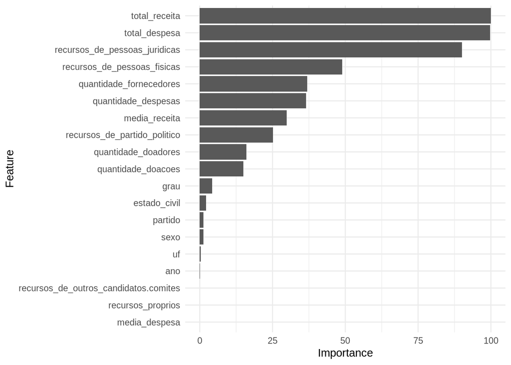

```r
ggplot(varImp(model.ridge))
```

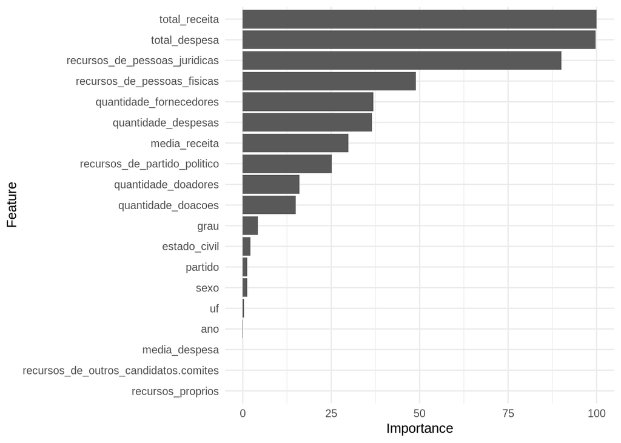

```r
ggplot(varImp(model.lasso))
```

**4. Re-treine o melhor modelo (usando os melhores valores de parâmetros encontrados em todos os dados, sem usar validação cruzada).**

```r
best.grid <- expand.grid(k = model.knn$bestTune)

best.model <- train(votos ~ .,
                    data = train,
                    method = "knn",
                    tuneGrid = best.grid)
best.model
```

```
## k-Nearest Neighbors
##
## 7476 samples
##   19 predictor
##
## No pre-processing
## Resampling: Bootstrapped (25 reps)
## Summary of sample sizes: 7476, 7476, 7476, 7476, 7476, 7476, ...
## Resampling results:
##
##   RMSE      Rsquared   MAE
##   35330.85  0.4670892  13344.2
##
## Tuning parameter 'k' was held constant at a value of 7
```

**5. Use esse último modelo treinado para prever os dados de teste disponíveis no challenge que criamos na plataforma Kaggle (Links para um site externo)**

```r
test <- read.csv("./test.csv")
submission <- test %>%
  select(sequencial_candidato)
test <- test %>%
  select(-sequencial_candidato,
         -nome,
         -cargo,
         -ocupacao)
predictions <- predict(best.model, test)
submission$votos <- predictions
submission <- submission %>%
  select(ID = sequencial_candidato,
         votos = votos)
write.csv(x = submission,
          file = "sample_submission.csv",
          row.names = FALSE)
```